# Coursework2

Sum Yu Ng

03/05/2021

# Time Series identification and estimation

## Introduction

In this report,I will identify,estimate and check of a the suitable model for the Nile dataset.

## Nile Data

First lets take a look at the Nile data. Nile data set is the measurements of the annual flow of the river Nile at Aswsan during 1871-1970.

```r
data("Nile")
help("Nile")
nile = Nile
nile
```

```
## Time Series:
## Start = 1871
## End = 1970
## Frequency = 1
##   [1] 1120 1160  963 1210 1160 1160  813 1230 1370 1140  995  935 1110  994 1020
##  [16]  960 1180  799  958 1140 1100 1210 1150 1250 1260 1220 1030 1100  774  840
##  [31]  874  694  940  833  701  916  692 1020 1050  969  831  726  456  824  702
##  [46] 1120 1100  832  764  821  768  845  864  862  698  845  744  796 1040  759
##  [61]  781  865  845  944  984  897  822 1010  771  676  649  846  812  742  801
##  [76] 1040  860  874  848  890  744  749  838 1050  918  986  797  923  975  815
##  [91] 1020  906  901 1170  912  746  919  718  714  740
```

Next,view the time series and observe whether the data appear reasonably stationary.

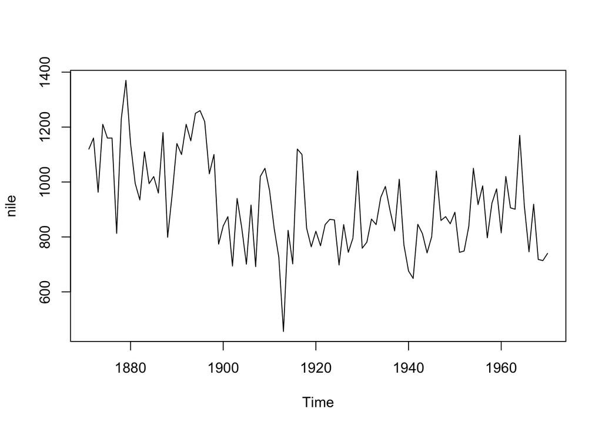

```r
#plot the time series
ts.plot(nile)
```

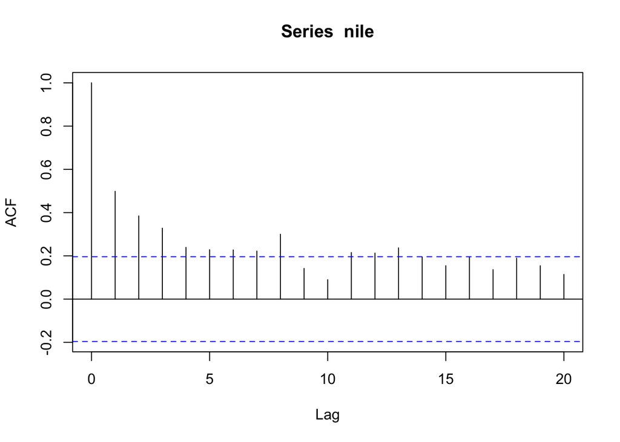

```r
acf(nile)
```

## Difference

Difference the data using the command

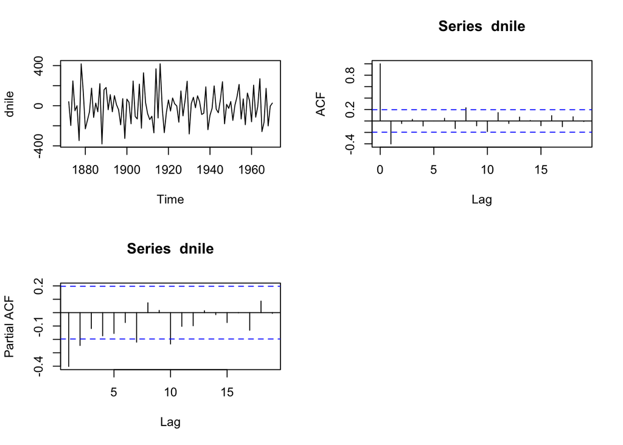

```r
dnile = diff(nile)
par(mfrow=c(2,2))
ts.plot(dnile)
acf(dnile)
pacf(dnile)
```

From the ACF plot shows a gradually decaying autocorrelation to 0 as the lags increase for an AR process. For an MA process,the ACF will exhibit a jump to 0 after the qth lag so from the above ACF plot we can say that here is a MA(1) compenent and there is also a second small pike it could be either MA(1) or MA(2).

From the PACF plot,there is clearly an AR(1) component, due to a big spike at lag 1 in the pacf. There is also a small spike at lag 2.

To be noted,the acf and pacf values can be treated as zero if they lie within the dotted blue lines and we only take the ones outside the blue lines into account.Although the second spike in the PACF plot is quite small. So, perhaps it could either be an AR(1) or an AR(2).

## fitting the model

In the following,we will try on (1,0,0) (2,0,0) (0,0,1) (0,0,2) first. Let’s fit an AR(1) to the difference data dnile. We use the arima command to fit the model by maximum likelihood.

```r
fit <- arima(dnile,order=c(1,0,0))
fit
```

```
##
## Call:
## arima(x = dnile, order = c(1, 0, 0))
##
## Coefficients:
##           ar1  intercept
##       -0.3984    -4.0514
## s.e.   0.0915    11.0386
##
## sigma^2 estimated as 23455:  log likelihood = -638.67,  aic = 1283.35
```

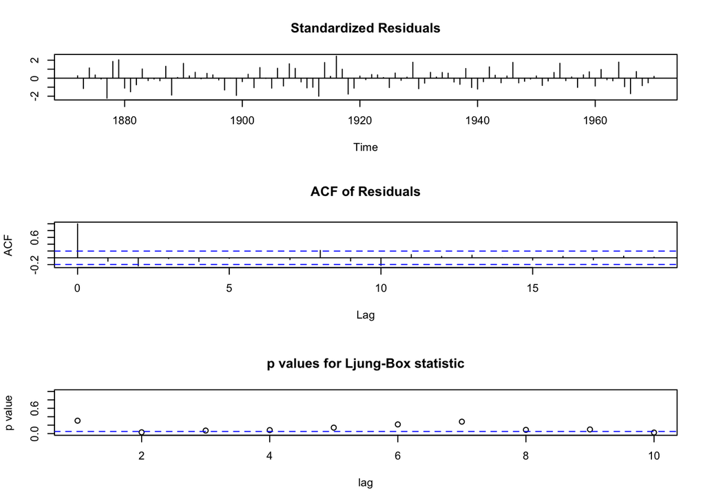

```r
tsdiag(fit)
```

This is not a good fit, as the Ljung-Box p-values should nearly all be above the blue line at 0.05.

Let’s now try fitting an AR(2).

```r
fit <- arima(dnile,order=c(2,0,0))
fit
```

```
##
## Call:
## arima(x = dnile, order = c(2, 0, 0))
##
## Coefficients:
##           ar1     ar2  intercept
##       -0.4965  -0.243    -3.8844
## s.e.   0.0971   0.097     8.6263
##
## sigma^2 estimated as 22035:  log likelihood = -635.64,  aic = 1279.28
```

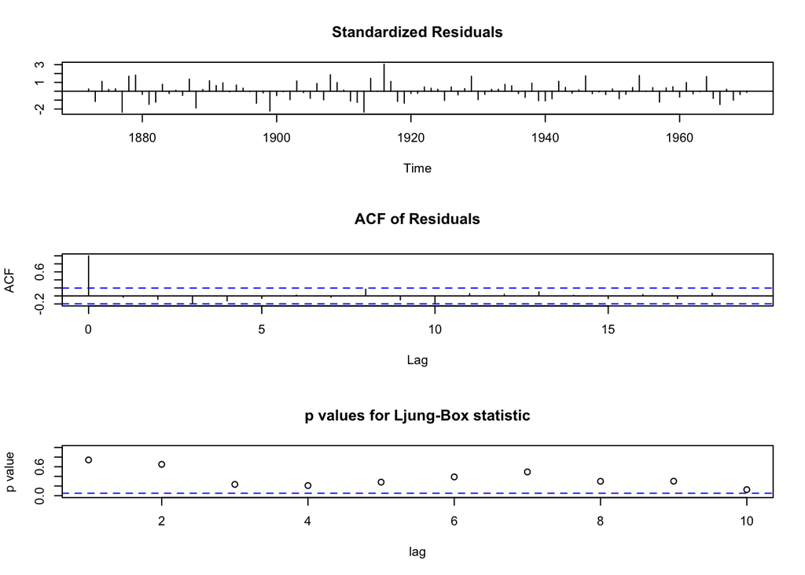

```r
tsdiag(fit)
```

This does seem a reasonable fit. The p=values are all above the blue line (0.05) and the acf of the residuals (middle plot) looks like that of white noise.

```r
fit2 <- arima(dnile,order=c(0,0,1))
fit2
```

```
##
## Call:
## arima(x = dnile, order = c(0, 0, 1))
##
## Coefficients:
##           ma1  intercept
##       -0.7646    -3.2583
## s.e.   0.1205     3.5165
##
## sigma^2 estimated as 20416:  log likelihood = -632.15,  aic = 1270.31
```

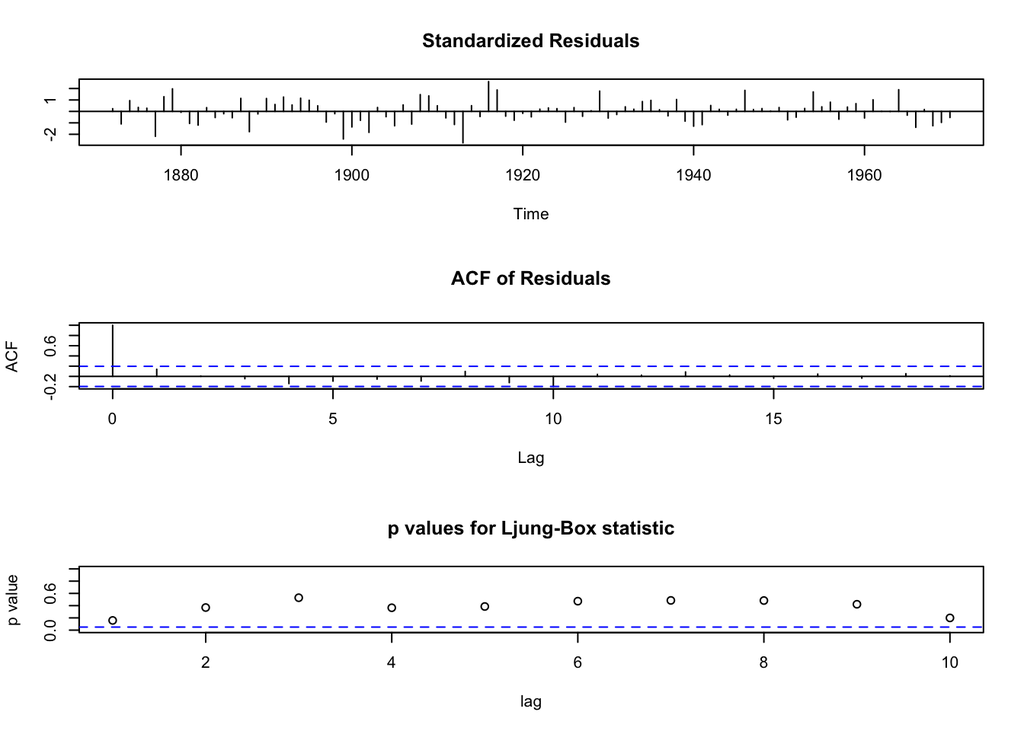

```r
tsdiag(fit2)
```

```r
fit3 <- arima(dnile,order=c(0,0,2))
fit3
```

```
##
## Call:
## arima(x = dnile, order = c(0, 0, 2))
##
## Coefficients:
##           ma1      ma2  intercept
##       -0.6634  -0.1895    -2.9210
## s.e.   0.0941   0.0946     2.2419
##
## sigma^2 estimated as 19593:  log likelihood = -630.27,  aic = 1268.54
```

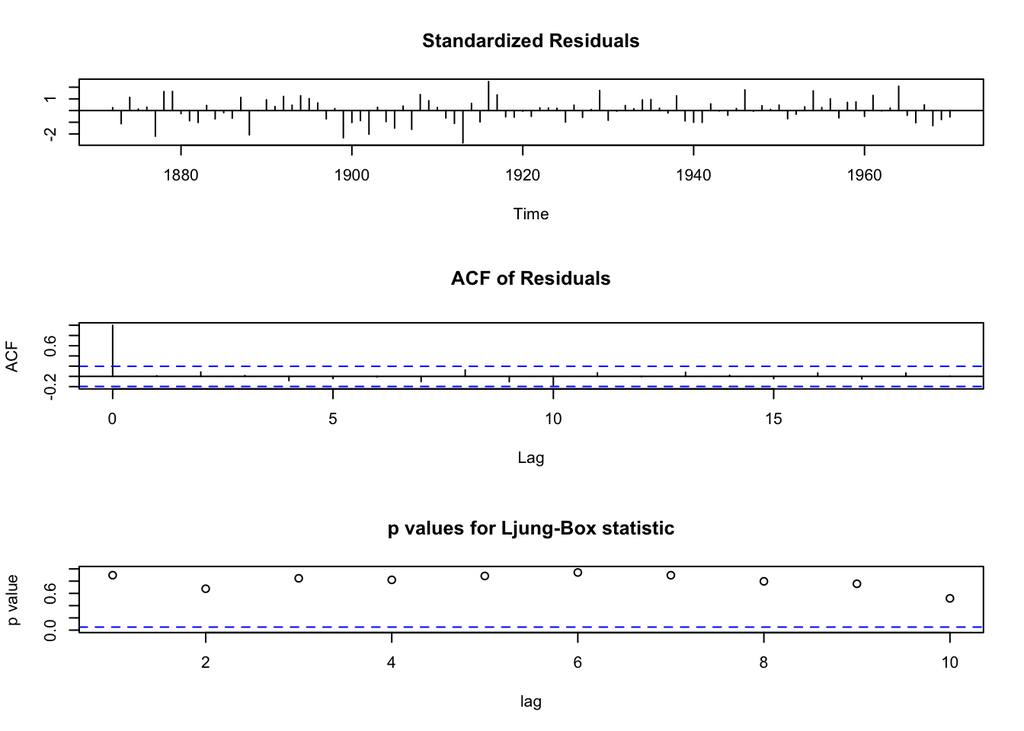

```r
tsdiag(fit3)
```

Both MA(1) and MA(2) are reasonable fit. The p=values are all above the blue line (0.05) and the acf of the residuals (middle plot) looks like that of white noise.

Therefore,there were three models which fit well the differenced data, AR(2),MA(1) and MA(2),using acf and pacf.

# Auto.ARIMA

Now we will use the forecast library to choose a model using the information criteria. Let’s work with the original time series nile first.

```r
library(forecast)
fit4 <-auto.arima(nile,ic="aicc")
fit4
```

```
## Series: nile
## ARIMA(1,1,1)
##
## Coefficients:
##          ar1      ma1
##       0.2544  -0.8741
## s.e.  0.1194   0.0605
##
## sigma^2 estimated as 20177:  log likelihood=-630.63
## AIC=1267.25   AICc=1267.51   BIC=1275.04
```

```r
auto.arima(nile,ic="aic")
```

```
## Series: nile
## ARIMA(1,1,1)
##
## Coefficients:
##          ar1      ma1
##       0.2544  -0.8741
## s.e.  0.1194   0.0605
##
## sigma^2 estimated as 20177:  log likelihood=-630.63
## AIC=1267.25   AICc=1267.51   BIC=1275.04
```

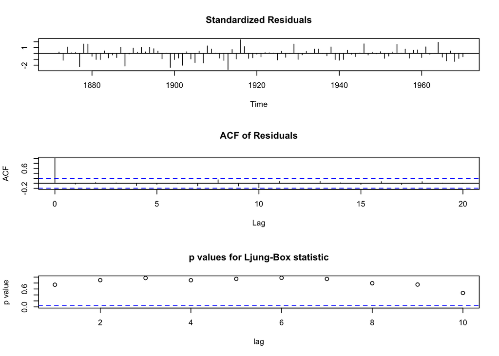

```r
tsdiag(fit4)
```

```r
fit5<- auto.arima(nile,ic="bic")
fit5
```

```
## Series: nile
## ARIMA(0,1,1)
##
## Coefficients:
##           ma1
##       -0.7329
## s.e.   0.1143
##
## sigma^2 estimated as 20810:  log likelihood=-632.55
## AIC=1269.09   AICc=1269.22   BIC=1274.28
```

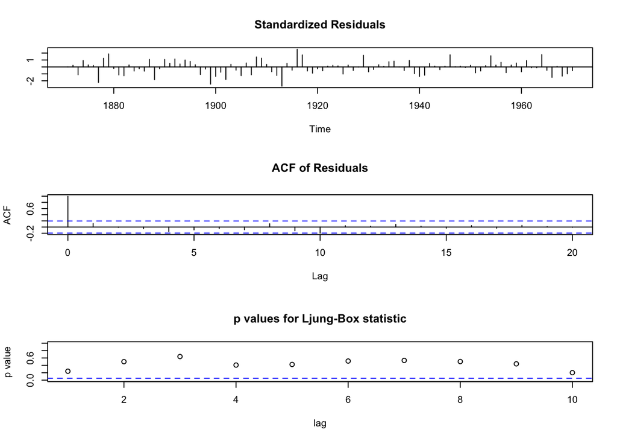

```r
tsdiag(fit5)
```

We can see that two different models,ARIMA(1,1,1) and ARIMA(0,1,1),are chosen by using the information criteria.

Alternatively we could work with the first difference series dnile directly.

```r
library("forecast")
auto.arima(dnile,ic="aicc")
```

```
## Series: dnile
## ARIMA(1,0,1) with zero mean
##
## Coefficients:
##          ar1      ma1
##       0.2544  -0.8741
## s.e.  0.1194   0.0605
##
## sigma^2 estimated as 20177:  log likelihood=-630.63
## AIC=1267.25   AICc=1267.51   BIC=1275.04
```

```r
fit6<-auto.arima(dnile,ic="aic")
fit6
```

```
## Series: dnile
## ARIMA(1,0,1) with zero mean
##
## Coefficients:
##          ar1      ma1
##       0.2544  -0.8741
## s.e.  0.1194   0.0605
##
## sigma^2 estimated as 20177:  log likelihood=-630.63
## AIC=1267.25   AICc=1267.51   BIC=1275.04
```

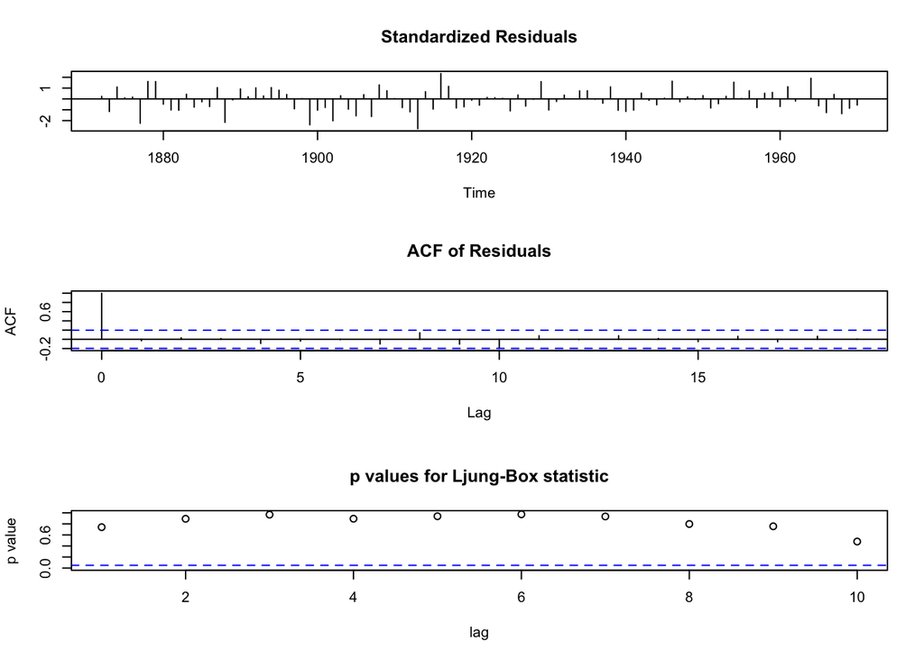

```r
tsdiag(fit6)
```

```r
fit7<- auto.arima(dnile,ic="bic")
fit7
```

```
## Series: dnile
## ARIMA(0,0,1) with zero mean
##
## Coefficients:
##           ma1
##       -0.7329
## s.e.   0.1143
##
## sigma^2 estimated as 20810:  log likelihood=-632.55
## AIC=1269.09   AICc=1269.22   BIC=1274.28
```

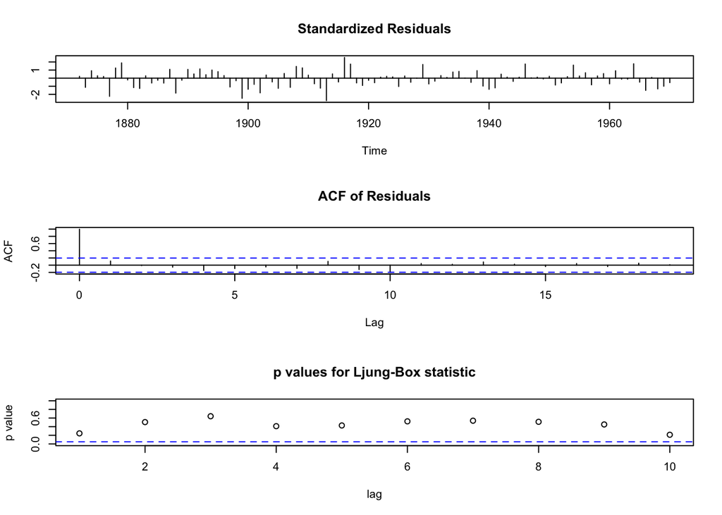

```r
tsdiag(fit7)
```

# Investigation This leads to the same models being chosen. So, for this dataset there were five models which fit well to the differenced data. AR(2),MA(1),MA(2) [using acf, pacf] but but MA(2) has the biggest likelihood so it would be considered as the best model in the first session.

Furthermore,ARIMA(1,1,1) and ARIMA(0,1,1) are the well fitting models for the dataset from the information criteria where ARIMA(1,1,1) is the having the largest likelihood.